# assignment_2

### Problem Statement 1: Samantha has created a dataset named 'top50spotify.csv' of her top 50 songs from spotify.

#### Tasks to be performed:

1. Import the dataset as a DataFrame and drop the first column.

```python
import numpy as np
import pandas as pd
```

```python
data = pd.read_csv("top50spotify.csv")
data.head()
```

|  | SerialNo. | Track.Name | Artist.Name | Genre | Beats.Per.Minute | Energy | Danceability | Loudness..dB.. | Liveness | Valence. | Length. | Acousticness.. | Speechiness. | Popularity |
| --- | --- | --- | --- | --- | --- | --- | --- | --- | --- | --- | --- | --- | --- | --- |
| 0 | 1 | Señorita | Shawn Mendes | canadian pop | 117 | 55 | 76 | -6 | 8 | 75 | 191 | 4 | 3 | 79 |
| 1 | 2 | China | Anuel AA | reggaeton flow | 105 | 81 | 79 | -4 | 8 | 61 | 302 | 8 | 9 | 92 |
| 2 | 3 | boyfriend (with Social House) | Ariana Grande | dance pop | 190 | 80 | 40 | -4 | 16 | 70 | 186 | 12 | 46 | 85 |
| 3 | 4 | Beautiful People (feat. Khalid) | Ed Sheeran | pop | 93 | 65 | 64 | -8 | 8 | 55 | 198 | 12 | 19 | 86 |
| 4 | 5 | Goodbyes (Feat. Young Thug) | Post Malone | dfw rap | 150 | 65 | 58 | -4 | 11 | 18 | 175 | 45 | 7 | 94 |

```python
df = data.drop(columns=['SerialNo.'], axis=1)
df.head()
```

|  | Track.Name | Artist.Name | Genre | Beats.Per.Minute | Energy | Danceability | Loudness..dB.. | Liveness | Valence. | Length. | Acousticness.. | Speechiness. | Popularity |
| --- | --- | --- | --- | --- | --- | --- | --- | --- | --- | --- | --- | --- | --- |
| 0 | Señorita | Shawn Mendes | canadian pop | 117 | 55 | 76 | -6 | 8 | 75 | 191 | 4 | 3 | 79 |
| 1 | China | Anuel AA | reggaeton flow | 105 | 81 | 79 | -4 | 8 | 61 | 302 | 8 | 9 | 92 |
| 2 | boyfriend (with Social House) | Ariana Grande | dance pop | 190 | 80 | 40 | -4 | 16 | 70 | 186 | 12 | 46 | 85 |
| 3 | Beautiful People (feat. Khalid) | Ed Sheeran | pop | 93 | 65 | 64 | -8 | 8 | 55 | 198 | 12 | 19 | 86 |
| 4 | Goodbyes (Feat. Young Thug) | Post Malone | dfw rap | 150 | 65 | 58 | -4 | 11 | 18 | 175 | 45 | 7 | 94 |

2. Save it as 'top50.csv'.

```python
df.to_csv("top50.csv")
```

3. Find the average Energy and Length of first 10 songs.

```python
df.columns
```

```
Index(['Track.Name', 'Artist.Name', 'Genre', 'Beats.Per.Minute', 'Energy',
       'Danceability', 'Loudness..dB..', 'Liveness', 'Valence.', 'Length.',
       'Acousticness..', 'Speechiness.', 'Popularity'],
      dtype='object')
```

```python
df[['Energy', 'Length.']].iloc[:10]
```

|  | Energy | Length. |
| --- | --- | --- |
| 0 | 55 | 191 |
| 1 | 81 | 302 |
| 2 | 80 | 186 |
| 3 | 65 | 198 |
| 4 | 65 | 175 |
| 5 | 68 | 220 |
| 6 | 64 | 131 |
| 7 | 68 | 202 |
| 8 | 62 | 157 |
| 9 | 43 | 194 |

```python
df[['Energy', 'Length.']].iloc[:10].mean()
```

```
Energy      65.1
Length.    195.6
dtype: float64
```

4. Find the total length of songs, group by genre from top to bottom.

```python
df.groupby(by=['Genre'])[['Length.']].sum()
```

| Genre | Length. |
| --- | --- |
| atl hip hop | 200 |
| australian pop | 210 |
| big room | 164 |
| boy band | 181 |
| brostep | 396 |
| canadian hip hop | 579 |
| canadian pop | 382 |
| country rap | 272 |
| dance pop | 1621 |
| dfw rap | 333 |
| edm | 656 |
| electropop | 389 |
| escape room | 173 |
| latin | 1126 |
| panamanian pop | 514 |
| pop | 1368 |
| pop house | 153 |
| r&b en espanol | 162 |
| reggaeton | 427 |
| reggaeton flow | 611 |
| trap music | 131 |

5. Print the artist name with the most number of tracks in one genre. (Hint: Group by artist name and genre)

```python
artist_genre_counts = df.groupby(by=['Artist.Name','Genre'])[['Track.Name']].count()
artist_genre_counts
```

| Artist.Name | Genre | Track.Name |
| --- | --- | --- |
| Ali Gatie | canadian hip hop | 1 |
| Anuel AA | reggaeton flow | 1 |
| Ariana Grande | dance pop | 2 |
| Bad Bunny | reggaeton | 1 |
| Billie Eilish | electropop | 2 |
| Chris Brown | dance pop | 1 |
| DJ Snake | dance pop | 1 |
| Daddy Yankee | latin | 1 |
| Drake | canadian hip hop | 1 |
| Ed Sheeran | pop | 4 |
| J Balvin | latin | 2 |
| Jhay Cortez | reggaeton flow | 1 |
| Jonas Brothers | boy band | 1 |
| Katy Perry | dance pop | 1 |
| Khalid | pop | 1 |
| Kygo | edm | 1 |
| Lady Gaga | dance pop | 1 |
| Lauv | dance pop | 1 |
| Lewis Capaldi | pop | 1 |
| Lil Nas X | country rap | 2 |
| Lil Tecca | trap music | 1 |
| Lizzo | escape room | 1 |
| Lunay | latin | 1 |
| MEDUZA | pop house | 1 |
| Maluma | reggaeton | 1 |
| Marshmello | brostep | 2 |
| Martin Garrix | big room | 1 |
| Nicky Jam | latin | 1 |
| Post Malone | dfw rap | 2 |
| ROSALÍA | r&b en espanol | 1 |
| Sam Smith | pop | 1 |
| Sech | panamanian pop | 2 |
| Shawn Mendes | canadian pop | 2 |
| Taylor Swift | dance pop | 1 |
| The Chainsmokers | edm | 2 |
| Tones and I | australian pop | 1 |
| Y2K | canadian hip hop | 1 |
| Young Thug | atl hip hop | 1 |

```python
artist_highest_no_tracks_in_one_genre = artist_genre_counts.loc[artist_genre_counts["Track.Name"] == 4].reset_index()
artist_highest_no_tracks_in_one_genre['Artist.Name']
```

```
0    Ed Sheeran
Name: Artist.Name, dtype: object
```

6. Print the data of the tracks created by the artist from the previous question.

```python
df.loc[df['Artist.Name'] == "Ed Sheeran"]
```

|  | Track.Name | Artist.Name | Genre | Beats.Per.Minute | Energy | Danceability | Loudness..dB.. | Liveness | Valence. | Length. | Acousticness.. | Speechiness. | Popularity |
| --- | --- | --- | --- | --- | --- | --- | --- | --- | --- | --- | --- | --- | --- |
| 3 | Beautiful People (feat. Khalid) | Ed Sheeran | pop | 93 | 65 | 64 | -8 | 8 | 55 | 198 | 12 | 19 | 86 |
| 5 | I Don't Care (with Justin Bieber) | Ed Sheeran | pop | 102 | 68 | 80 | -5 | 9 | 84 | 220 | 9 | 4 | 84 |
| 37 | Antisocial (with Travis Scott) | Ed Sheeran | pop | 152 | 82 | 72 | -5 | 36 | 91 | 162 | 13 | 5 | 87 |
| 49 | Cross Me (feat. Chance the Rapper & PnB Rock) | Ed Sheeran | pop | 95 | 79 | 75 | -6 | 7 | 61 | 206 | 21 | 12 | 82 |

### Problem Statement 2: Write a Python program to perform the following tasks

1. Create a pandas series from the below dictionary where indices are subjects

```python
subjects_std_score = {
'English':{'Sam':60,'Jackson':74,'Ahree':85},
'History':{'Gloria':83,'Sam':65,'Isla':78,'Aron':72,'Gray':61},
'Geography':{'Jackson':92,'Gloria':95,'Isla':82,'Aron':75,'Ahree':76},
'Mathematics':{'Sam':99,'Gloria':74,'Jackson':89,'Ahree':85,'Gray':95},
'Science':{'Sam':89,'Aron':82,'Gray':78,'Isla':93,'Ahree':87}
}
```

```python
subject_series = pd.Series(subjects_std_score)
subject_series
```

```
English                  {'Sam': 60, 'Jackson': 74, 'Ahree': 85}
History        {'Gloria': 83, 'Sam': 65, 'Isla': 78, 'Aron': ...
Geography      {'Jackson': 92, 'Gloria': 95, 'Isla': 82, 'Aro...
Mathematics    {'Sam': 99, 'Gloria': 74, 'Jackson': 89, 'Ahre...
Science        {'Sam': 89, 'Aron': 82, 'Gray': 78, 'Isla': 93...
dtype: object
```

2. Convert the created series into DataFrame and replace the null values with zeroes.

```python
df = subject_series.apply(pd.Series)
df
```

|  | Sam | Jackson | Ahree | Gloria | Isla | Aron | Gray |
| --- | --- | --- | --- | --- | --- | --- | --- |
| English | 60.0 | 74.0 | 85.0 | NaN | NaN | NaN | NaN |
| History | 65.0 | NaN | NaN | 83.0 | 78.0 | 72.0 | 61.0 |
| Geography | NaN | 92.0 | 76.0 | 95.0 | 82.0 | 75.0 | NaN |
| Mathematics | 99.0 | 89.0 | 85.0 | 74.0 | NaN | NaN | 95.0 |
| Science | 89.0 | NaN | 87.0 | NaN | 93.0 | 82.0 | 78.0 |

```python
df = df.fillna(0)
df
```

|  | Sam | Jackson | Ahree | Gloria | Isla | Aron | Gray |
| --- | --- | --- | --- | --- | --- | --- | --- |
| English | 60.0 | 74.0 | 85.0 | 0.0 | 0.0 | 0.0 | 0.0 |
| History | 65.0 | 0.0 | 0.0 | 83.0 | 78.0 | 72.0 | 61.0 |
| Geography | 0.0 | 92.0 | 76.0 | 95.0 | 82.0 | 75.0 | 0.0 |
| Mathematics | 99.0 | 89.0 | 85.0 | 74.0 | 0.0 | 0.0 | 95.0 |
| Science | 89.0 | 0.0 | 87.0 | 0.0 | 93.0 | 82.0 | 78.0 |

3. Transpose the DataFrame and create a new column 'Average' and fill the values in it by calculating the average of all subjects.

```python
df1 = df.transpose()
df1
```

|  | English | History | Geography | Mathematics | Science |
| --- | --- | --- | --- | --- | --- |
| Sam | 60.0 | 65.0 | 0.0 | 99.0 | 89.0 |
| Jackson | 74.0 | 0.0 | 92.0 | 89.0 | 0.0 |
| Ahree | 85.0 | 0.0 | 76.0 | 85.0 | 87.0 |
| Gloria | 0.0 | 83.0 | 95.0 | 74.0 | 0.0 |
| Isla | 0.0 | 78.0 | 82.0 | 0.0 | 93.0 |
| Aron | 0.0 | 72.0 | 75.0 | 0.0 | 82.0 |
| Gray | 0.0 | 61.0 | 0.0 | 95.0 | 78.0 |

```python
df1.info()
```

```
<class 'pandas.core.frame.DataFrame'>
Index: 7 entries, Sam to Gray
Data columns (total 5 columns):
 #   Column       Non-Null Count  Dtype
---  ------       --------------  -----
 0   English      7 non-null      float64
 1   History      7 non-null      float64
 2   Geography    7 non-null      float64
 3   Mathematics  7 non-null      float64
 4   Science      7 non-null      float64
dtypes: float64(5)
memory usage: 636.0+ bytes
```

```python
df1['Average'] = df1.mean(axis=1)
df1
```

|  | English | History | Geography | Mathematics | Science | Average |
| --- | --- | --- | --- | --- | --- | --- |
| Sam | 60.0 | 65.0 | 0.0 | 99.0 | 89.0 | 62.6 |
| Jackson | 74.0 | 0.0 | 92.0 | 89.0 | 0.0 | 51.0 |
| Ahree | 85.0 | 0.0 | 76.0 | 85.0 | 87.0 | 66.6 |
| Gloria | 0.0 | 83.0 | 95.0 | 74.0 | 0.0 | 50.4 |
| Isla | 0.0 | 78.0 | 82.0 | 0.0 | 93.0 | 50.6 |
| Aron | 0.0 | 72.0 | 75.0 | 0.0 | 82.0 | 45.8 |
| Gray | 0.0 | 61.0 | 0.0 | 95.0 | 78.0 | 46.8 |

### Problem Statement 3: Write a Python program to create a series from 1 to 1000 and select only numbers divisible by 7 and 17.

```python
num_range = np.arange(1,1001)
range_series = pd.Series(num_range)
range_series
```

```
0         1
1         2
2         3
3         4
4         5
       ...
995     996
996     997
997     998
998     999
999    1000
Length: 1000, dtype: int32
```

```python
filtered_numbers = range_series[(range_series % 7 == 0) & (range_series % 17 == 0)]
```

```python
filtered_numbers
```

```
118    119
237    238
356    357
475    476
594    595
713    714
832    833
951    952
dtype: int32
```

### Problem Statement 4: Sylphia has a dataset of various cereals sold in the supermarket.

#### Tasks to be performed:

1. Import the dataset.

```python
cereal_df = pd.read_csv("cereal.csv")
cereal_df
```

|  | name | mfr | type | calories | protein | fat | sodium | fiber | carbo | sugars | potass | vitamins | shelf | weight | cups | rating |
| --- | --- | --- | --- | --- | --- | --- | --- | --- | --- | --- | --- | --- | --- | --- | --- | --- |
| 0 | 100% Bran | N | C | 70 | 4 | 1 | 130 | 10.0 | 5.0 | 6 | 280.0 | 25 | 3 | 1.0 | 0.33 | 68.402973 |
| 1 | 100% Natural Bran | Q | C | 120 | 3 | 5 | 15 | 2.0 | 8.0 | 8 | 135.0 | 0 | 3 | 1.0 | 1.00 | 33.983679 |
| 2 | All-Bran | K | C | 70 | 4 | 1 | 260 | 9.0 | 7.0 | 5 | 320.0 | 25 | 3 | 1.0 | 0.33 | 59.425505 |
| 3 | All-Bran with Extra Fiber | K | C | 50 | 4 | 0 | 140 | 14.0 | 8.0 | 0 | 330.0 | 25 | 3 | 1.0 | 0.50 | 93.704912 |
| 4 | Almond Delight | R | C | 110 | 2 | 2 | 200 | 1.0 | 14.0 | 8 | NaN | 25 | 3 | 1.0 | 0.75 | 34.384843 |
| ... | ... | ... | ... | ... | ... | ... | ... | ... | ... | ... | ... | ... | ... | ... | ... | ... |
| 72 | Triples | G | C | 110 | 2 | 1 | 250 | 0.0 | 21.0 | 3 | 60.0 | 25 | 3 | 1.0 | 0.75 | 39.106174 |
| 73 | Trix | G | C | 110 | 1 | 1 | 140 | 0.0 | 13.0 | 12 | 25.0 | 25 | 2 | 1.0 | 1.00 | 27.753301 |
| 74 | Wheat Chex | R | C | 100 | 3 | 1 | 230 | 3.0 | 17.0 | 3 | 115.0 | 25 | 1 | 1.0 | 0.67 | 49.787445 |
| 75 | Wheaties | G | C | 100 | 3 | 1 | 200 | 3.0 | 17.0 | 3 | 110.0 | 25 | 1 | 1.0 | 1.00 | 51.592193 |
| 76 | Wheaties Honey Gold | G | C | 110 | 2 | 1 | 200 | 1.0 | 16.0 | 8 | 60.0 | 25 | 1 | 1.0 | 0.75 | 36.187559 |

77 rows × 16 columns

2. Plot ratings of different types of manufacturers.

```python
import matplotlib.pyplot  as plt
import seaborn as sns
```

```python
cereal_df.columns
```

```
Index(['name', 'mfr', 'type', 'calories', 'protein', 'fat', 'sodium', 'fiber',
       'carbo', 'sugars', 'potass', 'vitamins', 'shelf', 'weight', 'cups',
       'rating'],
      dtype='object')
```

```python
manuf_rating = cereal_df.groupby(['mfr'])[['rating']].sum().reset_index()
manuf_rating
```

|  | mfr | rating |
| --- | --- | --- |
| 0 | A | 54.850917 |
| 1 | G | 758.688737 |
| 2 | K | 1012.884634 |
| 3 | N | 407.811403 |
| 4 | P | 375.351697 |
| 5 | Q | 343.327919 |
| 6 | R | 332.343977 |

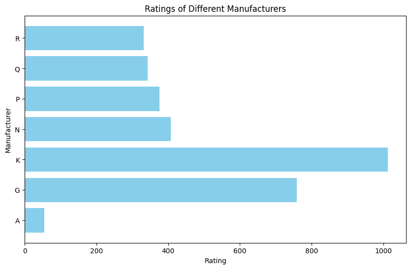

```python
plt.figure(figsize=(10, 6))
plt.barh(manuf_rating['mfr'], manuf_rating['rating'], color='skyblue')
plt.ylabel('Manufacturer')
plt.xlabel('Rating')
plt.title('Ratings of Different Manufacturers')
plt.show()
```

3. Use xticks range form 0-100.

```python
manuf_rating_count = cereal_df.groupby(['mfr'])[['rating']].count().reset_index()
manuf_rating_count
```

|  | mfr | rating |
| --- | --- | --- |
| 0 | A | 1 |
| 1 | G | 22 |
| 2 | K | 23 |
| 3 | N | 6 |
| 4 | P | 9 |
| 5 | Q | 8 |
| 6 | R | 8 |

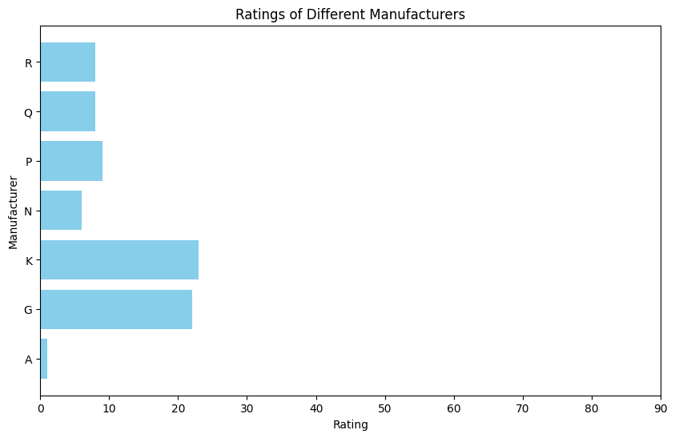

```python
plt.figure(figsize=(10, 6))
plt.barh(manuf_rating_count['mfr'], manuf_rating_count['rating'], color='skyblue')
plt.ylabel('Manufacturer')
plt.xlabel('Rating')
plt.title('Ratings of Different Manufacturers')
plt.xticks(range(0, 100, 10))
plt.show()
```

4. Change the style of the graph to seaborn

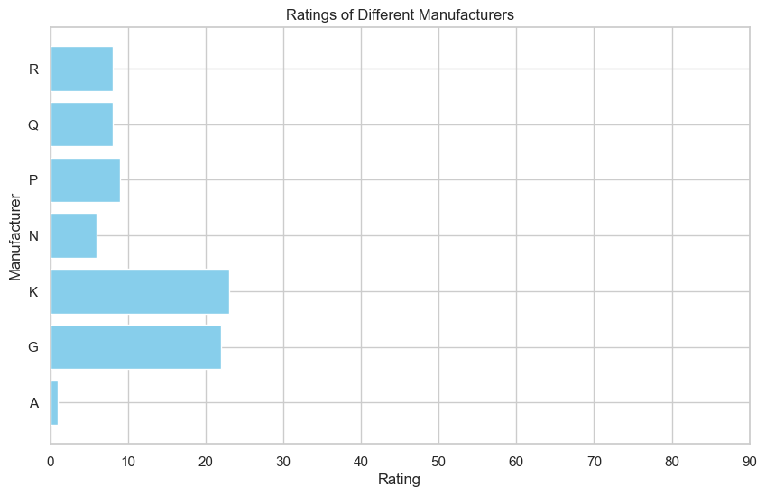

```python
# Set Seaborn style
sns.set(style="whitegrid")

plt.figure(figsize=(10, 6))
plt.barh(manuf_rating_count['mfr'], manuf_rating_count['rating'], color='skyblue')
plt.ylabel('Manufacturer')
plt.xlabel('Rating')
plt.title('Ratings of Different Manufacturers')
plt.xticks(range(0, 100, 10))
plt.show()
```